# ANOVA for a RCBD trial: SPYLPT2013_GH-Tono

## Computational tools

This report was created using i386-w64-mingw32, i386, mingw32, i386, mingw32, Revised, 3, 2.4, 2016, 03, 16, 70336, R, R version 3.2.4 Revised (2016-03-16 r70336), Very Secure Dishes on a i386-w64-mingw32/i386 (32-bit) running Windows 7 x64 (build 7601) Service Pack 1 in . The following base packages were loaded: **stats, graphics, grDevices, utils, datasets, methods, base** and the following additional packages: **magrittr, knitr, shiny**.

# Results

## Trait analyses

The following traits were not analyzed since they had too many missing values (>= 10%): Beta carotene content measuring mg per 100g, Content of iron on dry weight basis measuring mg per 100g, Content of zinc on dry weight basis measuring mg per 100g, Dry weight of storage root samples measuring g of sample, Fresh weight of storage root samples measuring g of sample, Fructose content measuring percent, Glucose content measuring percent, Harvest index computing percent, Number of commercial storage roots counting number per plot, Number of non-commercial storage roots counting number per plot, Plants with storage roots counting number per plot, Protein content measuring percent, Storage root dry matter content computing percent, Storage root starch content measuring percent, Sucrose content measuring percent, Weight of commercial storage roots measuring kg per plot, Weight of non-commercial storage roots measuring kg per plot. For the remaining traits missing values were imputed using all available information.

Valid traits: **Plants harvested counting number per plot, Plants planted counting number per plot, Storage root damages estimatimg 1-9, Storage root size estimating 1-9, Survival index computing percent, Sweet potato weevil symptoms 1 estimating 1-9, Vine vigor 1 estimating 1-9, Virus symptoms 2 estimating 1-9, Weight of vines measuring kg per plot**.

### Analysis of **Plants harvested counting number per plot**

You have fitted a linear model for a RCBD. The ANOVA table for your model is:

|  | Df | Sum Sq | Mean Sq | F value | Pr(>F) |
| --- | --- | --- | --- | --- | --- |
| **germplasmName** | 162 | 1719.95 | 10.617 | 2.41323 | 1.78229e-08 |
| **REP** | 1 | 4.97541 | 4.97541 | 1.13091 | 0.289165 |
| **Residuals** | 162 | 712.718 | 4.39949 | NA | NA |

The p-value for treatments is 0.0000000178229 which is significant at the 5% level.

The means of your treatments are:

| germplasmName | Plants harvested counting number per plot |
| --- | --- |
| Apomuden | 8.5 |
| Ogyefo | 7.5 |
| PG12005-1 | 8.5 |
| PG12005-105 | 5 |
| PG12005-24 | 5 |
| PG12005-35 | 8 |
| PG12005-52 | 10 |
| PG12005-55 | 2 |
| PG12005-79 | 4.5 |
| PG12005-82 | 8.5 |
| PG12005-88 | 7.5 |
| PG12010-15 | 8 |
| PG12011-7 | 2.49 |
| PG12012-1 | 4.5 |
| PG12012-2 | 3.5 |
| PG12012-4 | 2 |
| PG12014-2 | 2 |
| PG12021-10 | 5 |
| PG12021-7 | 5.8 |
| PG12028-4 | 2 |
| PG12047-3 | 7.5 |
| PG12055-14 | 5.72 |
| PG12057-14 | 3 |
| PG12058-15 | 2.28 |
| PG12059-14 | 3.5 |
| PG12059-8 | 4 |
| PG12061-13 | 7 |
| PG12064-5 | 4.01 |
| PG12069-11 | 3.78 |
| PG12070-14 | 1 |

[output cut: 133 more lines]

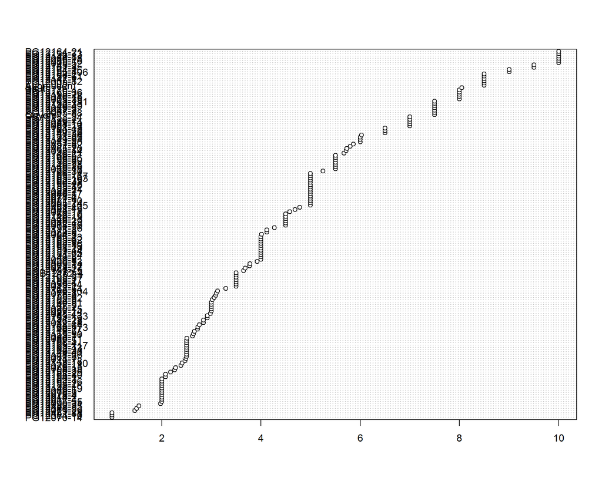

Do not forget the assumptions of the model. It is supposed that the error has a normal distribution with the same variance for all the treatments. The following plots must help you evaluate this:

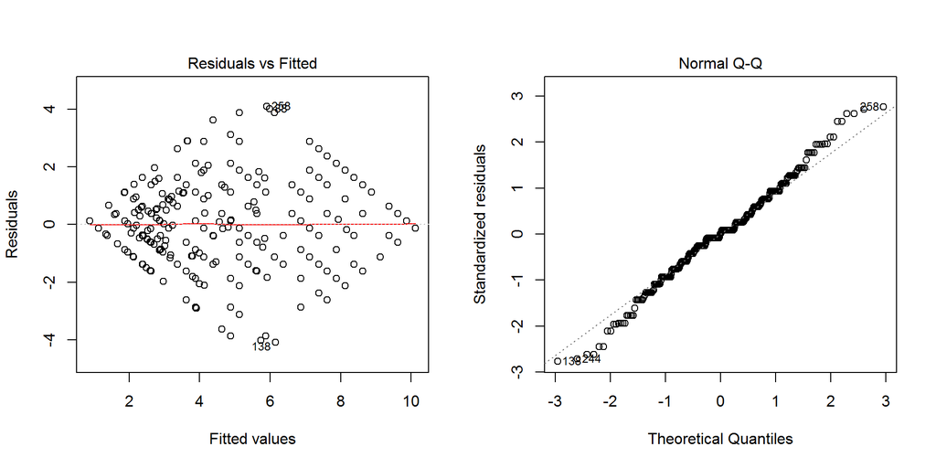

Funnel shapes for the first plot may suggest heterogeneity of variances while departures from the theoretical normal line are symptoms of lack of normality.

### Analysis of **Plants planted counting number per plot**

You have fitted a linear model for a RCBD. The ANOVA table for your model is:

|  | Df | Sum Sq | Mean Sq | F value | Pr(>F) |
| --- | --- | --- | --- | --- | --- |
| **germplasmName** | 162 | 3.91816e-29 | 2.41861e-31 | 1 | 0.5 |
| **REP** | 1 | 2.41861e-31 | 2.41861e-31 | 1 | 0.318802 |
| **Residuals** | 162 | 3.91816e-29 | 2.41861e-31 | NA | NA |

The means of your treatments are:

| germplasmName | Plants planted counting number per plot |
| --- | --- |
| Apomuden | 10 |
| Ogyefo | 10 |
| PG12005-1 | 10 |
| PG12005-105 | 10 |
| PG12005-24 | 10 |
| PG12005-35 | 10 |
| PG12005-52 | 10 |
| PG12005-55 | 10 |
| PG12005-79 | 10 |
| PG12005-82 | 10 |
| PG12005-88 | 10 |
| PG12010-15 | 10 |
| PG12011-7 | 10 |
| PG12012-1 | 10 |
| PG12012-2 | 10 |
| PG12012-4 | 10 |
| PG12014-2 | 10 |
| PG12021-10 | 10 |
| PG12021-7 | 10 |
| PG12028-4 | 10 |
| PG12047-3 | 10 |
| PG12055-14 | 10 |
| PG12057-14 | 10 |
| PG12058-15 | 10 |
| PG12059-14 | 10 |
| PG12059-8 | 10 |
| PG12061-13 | 10 |
| PG12064-5 | 10 |
| PG12069-11 | 10 |
| PG12070-14 | 10 |

[output cut: 133 more lines]

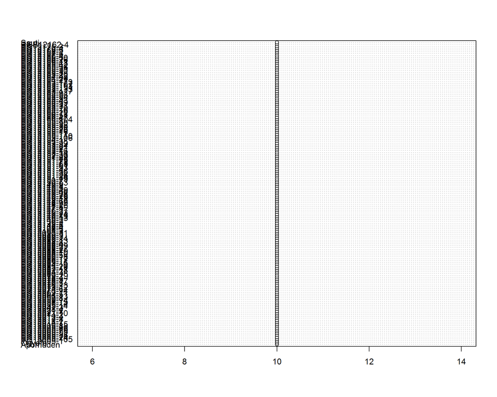

Do not forget the assumptions of the model. It is supposed that the error has a normal distribution with the same variance for all the treatments. The following plots must help you evaluate this:

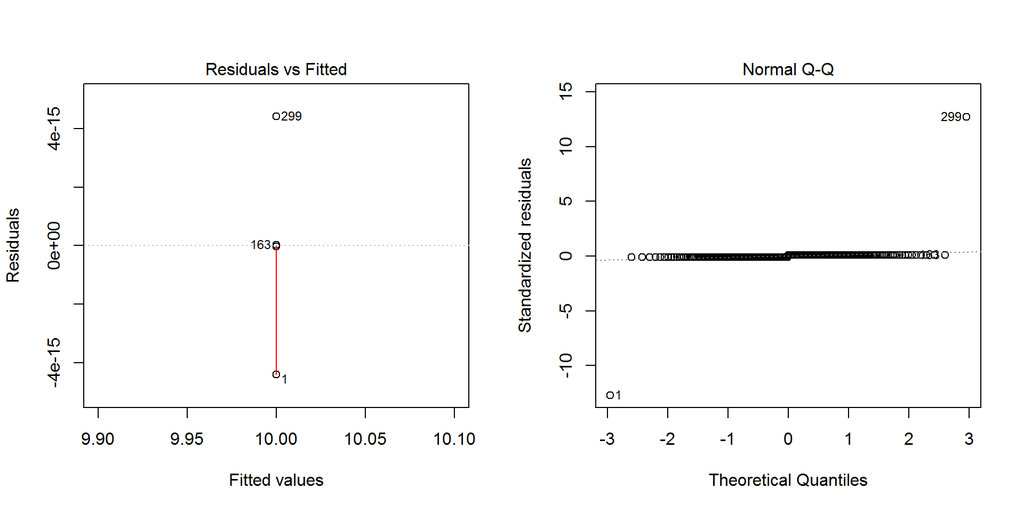

Funnel shapes for the first plot may suggest heterogeneity of variances while departures from the theoretical normal line are symptoms of lack of normality.

### Analysis of **Storage root damages estimatimg 1-9**

You have fitted a linear model for a RCBD. The ANOVA table for your model is:

|  | Df | Sum Sq | Mean Sq | F value | Pr(>F) |
| --- | --- | --- | --- | --- | --- |
| **germplasmName** | 162 | 458.331 | 2.82921 | 2.1394 | 8.93278e-07 |
| **REP** | 1 | 1.76687 | 1.76687 | 1.33608 | 0.249428 |
| **Residuals** | 162 | 214.233 | 1.32243 | NA | NA |

The p-value for treatments is 0.000000893278 which is significant at the 5% level.

The means of your treatments are:

| germplasmName | Storage root damages estimatimg 1-9 |
| --- | --- |
| Apomuden | 6.5 |
| Ogyefo | 1.5 |
| PG12005-1 | 2 |
| PG12005-105 | 1.5 |
| PG12005-24 | 1 |
| PG12005-35 | 1.5 |
| PG12005-52 | 1 |
| PG12005-55 | 4 |
| PG12005-79 | 1.5 |
| PG12005-82 | 1 |
| PG12005-88 | 2 |
| PG12010-15 | 1.5 |
| PG12011-7 | 1 |
| PG12012-1 | 1.5 |
| PG12012-2 | 1.5 |
| PG12012-4 | 1.5 |
| PG12014-2 | 2 |
| PG12021-10 | 1 |
| PG12021-7 | 1 |
| PG12028-4 | 1 |
| PG12047-3 | 2 |
| PG12055-14 | 1 |
| PG12057-14 | 1 |
| PG12058-15 | 1 |
| PG12059-14 | 1 |
| PG12059-8 | 2 |
| PG12061-13 | 1 |
| PG12064-5 | 1 |
| PG12069-11 | 1 |
| PG12070-14 | 1 |

[output cut: 133 more lines]

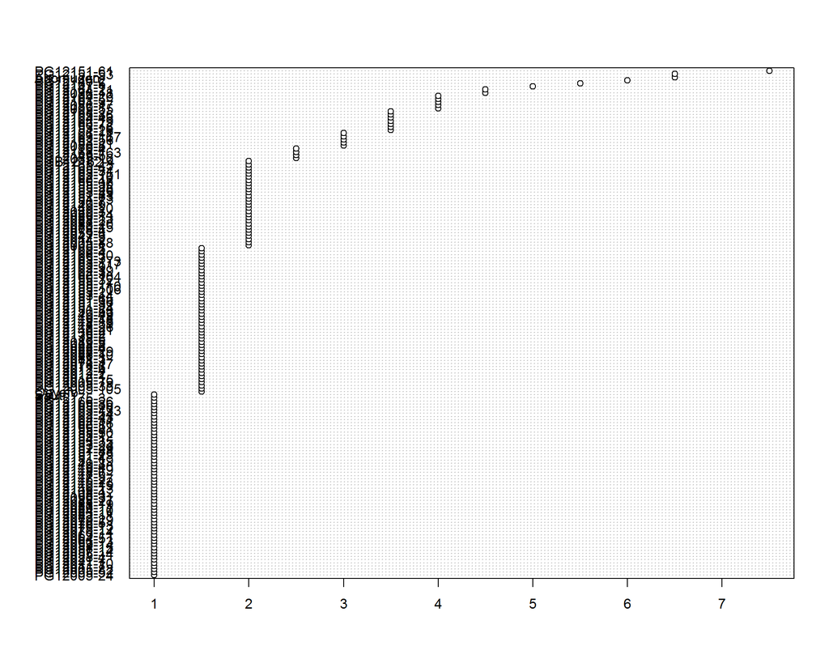

Do not forget the assumptions of the model. It is supposed that the error has a normal distribution with the same variance for all the treatments. The following plots must help you evaluate this:

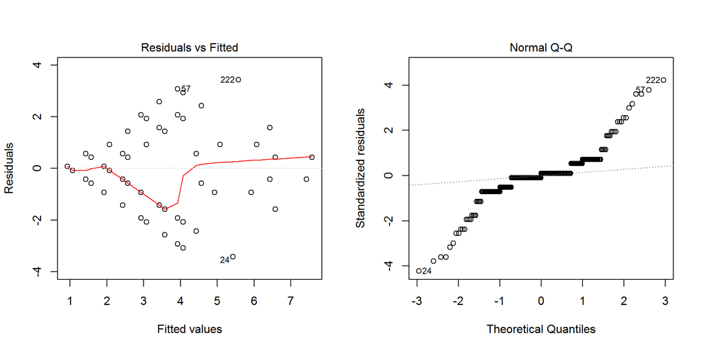

Funnel shapes for the first plot may suggest heterogeneity of variances while departures from the theoretical normal line are symptoms of lack of normality.

### Analysis of **Storage root size estimating 1-9**

You have fitted a linear model for a RCBD. The ANOVA table for your model is:

|  | Df | Sum Sq | Mean Sq | F value | Pr(>F) |
| --- | --- | --- | --- | --- | --- |
| **germplasmName** | 162 | 876.81 | 5.41241 | 2.03898 | 3.72307e-06 |
| **REP** | 1 | 3.97546 | 3.97546 | 1.49765 | 0.222811 |
| **Residuals** | 162 | 430.025 | 2.65447 | NA | NA |

The p-value for treatments is 0.00000372307 which is significant at the 5% level.

The means of your treatments are:

| germplasmName | Storage root size estimating 1-9 |
| --- | --- |
| Apomuden | 6 |
| Ogyefo | 2.5 |
| PG12005-1 | 4 |
| PG12005-105 | 2 |
| PG12005-24 | 1 |
| PG12005-35 | 2 |
| PG12005-52 | 1 |
| PG12005-55 | 1.5 |
| PG12005-79 | 2 |
| PG12005-82 | 1 |
| PG12005-88 | 2.5 |
| PG12010-15 | 4 |
| PG12011-7 | 1 |
| PG12012-1 | 3 |
| PG12012-2 | 2.5 |
| PG12012-4 | 2 |
| PG12014-2 | 2.5 |
| PG12021-10 | 1 |
| PG12021-7 | 1 |
| PG12028-4 | 1 |
| PG12047-3 | 3 |
| PG12055-14 | 1 |
| PG12057-14 | 1 |
| PG12058-15 | 1 |
| PG12059-14 | 1 |
| PG12059-8 | 3.5 |
| PG12061-13 | 1 |
| PG12064-5 | 1 |
| PG12069-11 | 1 |
| PG12070-14 | 1 |

[output cut: 133 more lines]

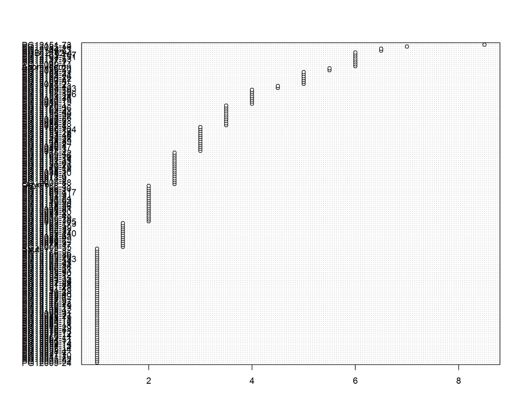

Do not forget the assumptions of the model. It is supposed that the error has a normal distribution with the same variance for all the treatments. The following plots must help you evaluate this:

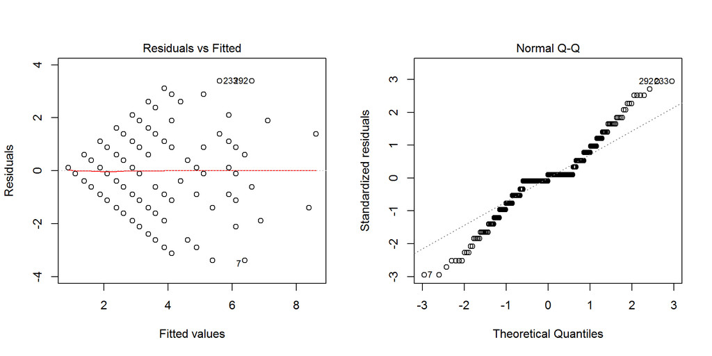

Funnel shapes for the first plot may suggest heterogeneity of variances while departures from the theoretical normal line are symptoms of lack of normality.

### Analysis of **Survival index computing percent**

You have fitted a linear model for a RCBD. The ANOVA table for your model is:

|  | Df | Sum Sq | Mean Sq | F value | Pr(>F) |
| --- | --- | --- | --- | --- | --- |
| **germplasmName** | 162 | 17.1995 | 0.10617 | 2.41323 | 1.78229e-08 |
| **REP** | 1 | 0.0497541 | 0.0497541 | 1.13091 | 0.289165 |
| **Residuals** | 162 | 7.12718 | 0.0439949 | NA | NA |

The p-value for treatments is 0.0000000178229 which is significant at the 5% level.

The means of your treatments are:

| germplasmName | Survival index computing percent |
| --- | --- |
| Apomuden | 0.85 |
| Ogyefo | 0.75 |
| PG12005-1 | 0.85 |
| PG12005-105 | 0.5 |
| PG12005-24 | 0.5 |
| PG12005-35 | 0.8 |
| PG12005-52 | 1 |
| PG12005-55 | 0.2 |
| PG12005-79 | 0.45 |
| PG12005-82 | 0.85 |
| PG12005-88 | 0.75 |
| PG12010-15 | 0.8 |
| PG12011-7 | 0.249 |
| PG12012-1 | 0.45 |
| PG12012-2 | 0.35 |
| PG12012-4 | 0.2 |
| PG12014-2 | 0.2 |
| PG12021-10 | 0.5 |
| PG12021-7 | 0.58 |
| PG12028-4 | 0.2 |
| PG12047-3 | 0.75 |
| PG12055-14 | 0.572 |
| PG12057-14 | 0.3 |
| PG12058-15 | 0.228 |
| PG12059-14 | 0.35 |
| PG12059-8 | 0.4 |
| PG12061-13 | 0.7 |
| PG12064-5 | 0.401 |
| PG12069-11 | 0.378 |
| PG12070-14 | 0.1 |

[output cut: 133 more lines]

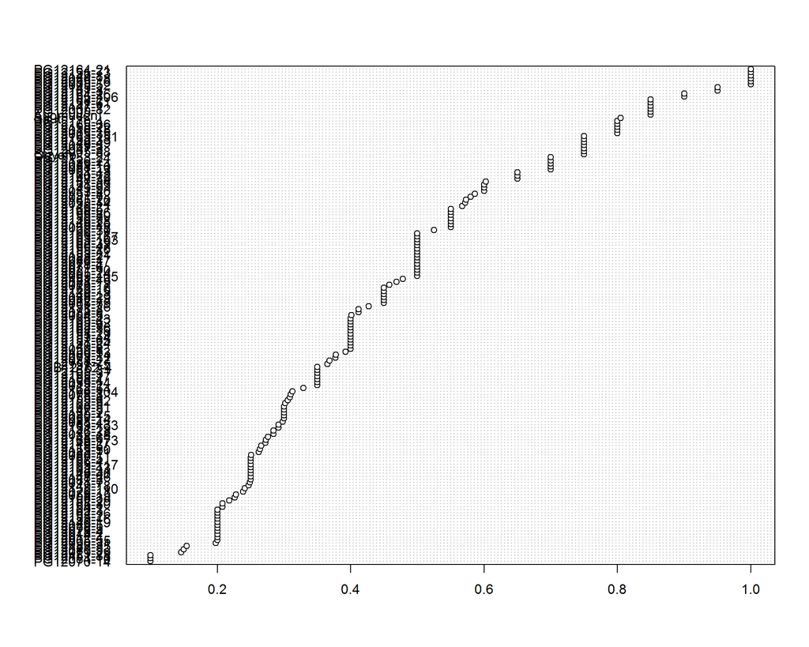

Do not forget the assumptions of the model. It is supposed that the error has a normal distribution with the same variance for all the treatments. The following plots must help you evaluate this:

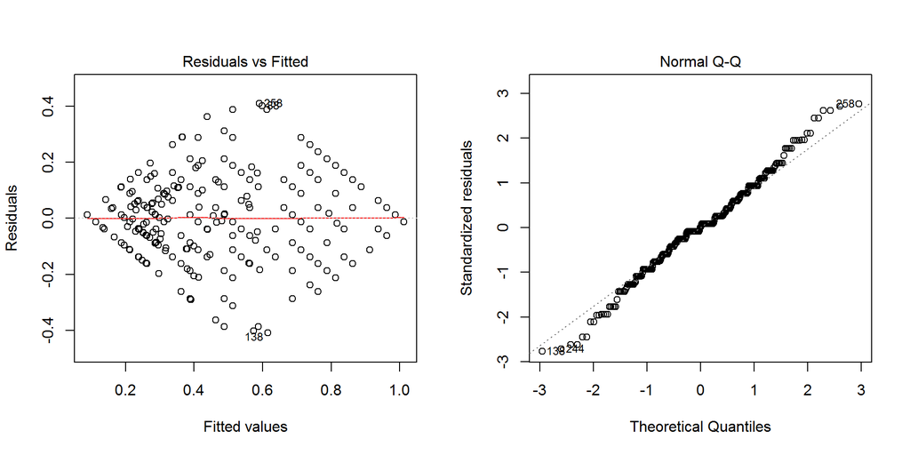

Funnel shapes for the first plot may suggest heterogeneity of variances while departures from the theoretical normal line are symptoms of lack of normality.

### Analysis of **Sweet potato weevil symptoms 1 estimating 1-9**

You have fitted a linear model for a RCBD. The ANOVA table for your model is:

|  | Df | Sum Sq | Mean Sq | F value | Pr(>F) |
| --- | --- | --- | --- | --- | --- |
| **germplasmName** | 162 | 149.16 | 0.920738 | 1.41742 | 0.013518 |
| **REP** | 1 | 1.76687 | 1.76687 | 2.71999 | 0.101036 |
| **Residuals** | 162 | 105.233 | 0.649587 | NA | NA |

The p-value for treatments is 0.013518 which is significant at the 5% level.

The means of your treatments are:

| germplasmName | Sweet potato weevil symptoms 1 estimating 1-9 |
| --- | --- |
| Apomuden | 4 |
| Ogyefo | 1.5 |
| PG12005-1 | 2 |
| PG12005-105 | 1.5 |
| PG12005-24 | 1 |
| PG12005-35 | 1.5 |
| PG12005-52 | 1 |
| PG12005-55 | 1.5 |
| PG12005-79 | 1.5 |
| PG12005-82 | 1 |
| PG12005-88 | 2 |
| PG12010-15 | 1.5 |
| PG12011-7 | 1 |
| PG12012-1 | 1.5 |
| PG12012-2 | 1.5 |
| PG12012-4 | 1.5 |
| PG12014-2 | 1.5 |
| PG12021-10 | 1 |
| PG12021-7 | 1 |
| PG12028-4 | 1 |
| PG12047-3 | 2 |
| PG12055-14 | 1 |
| PG12057-14 | 1 |
| PG12058-15 | 1 |
| PG12059-14 | 1 |
| PG12059-8 | 4 |
| PG12061-13 | 1 |
| PG12064-5 | 1 |
| PG12069-11 | 1 |
| PG12070-14 | 1 |

[output cut: 133 more lines]

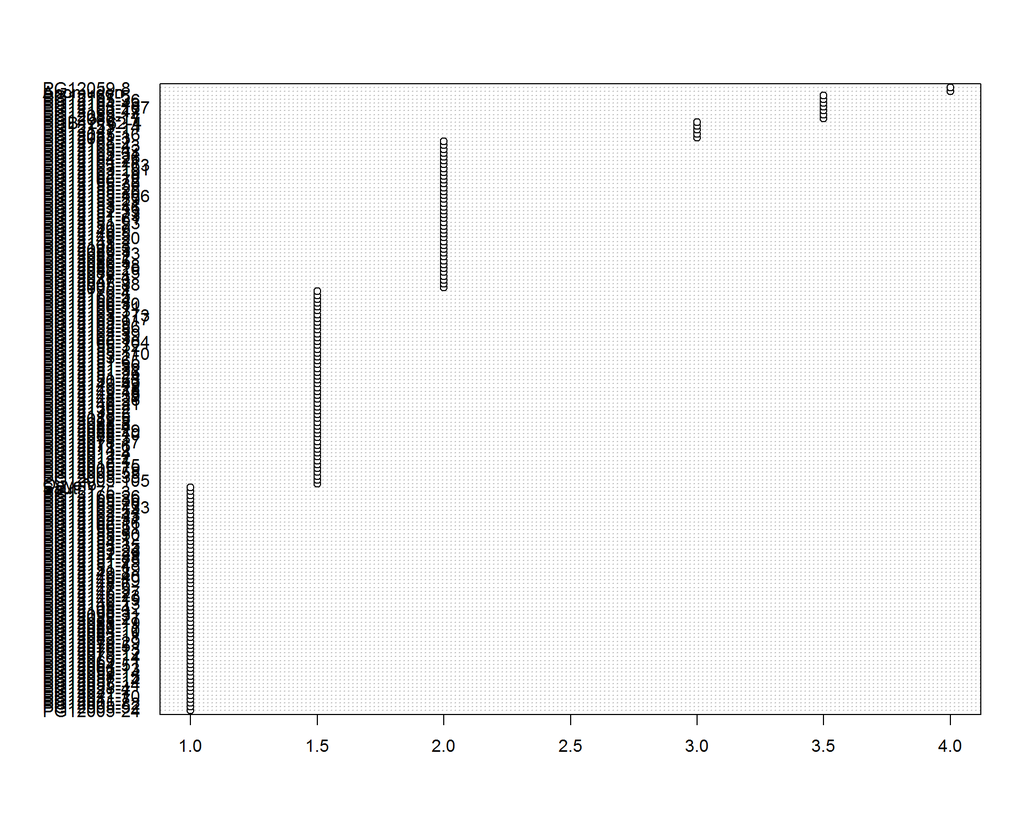

Do not forget the assumptions of the model. It is supposed that the error has a normal distribution with the same variance for all the treatments. The following plots must help you evaluate this:

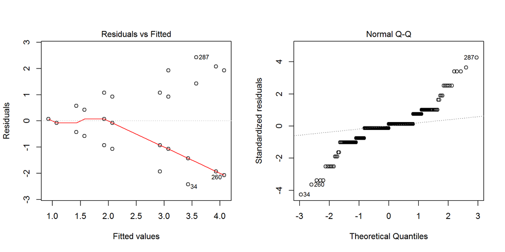

Funnel shapes for the first plot may suggest heterogeneity of variances while departures from the theoretical normal line are symptoms of lack of normality.

### Analysis of **Vine vigor 1 estimating 1-9**

You have fitted a linear model for a RCBD. The ANOVA table for your model is:

|  | Df | Sum Sq | Mean Sq | F value | Pr(>F) |
| --- | --- | --- | --- | --- | --- |
| **germplasmName** | 162 | 2434.2 | 15.0259 | 3.3211 | 6.07441e-14 |
| **REP** | 1 | 0.0490798 | 0.0490798 | 0.0108478 | 0.917177 |
| **Residuals** | 162 | 732.951 | 4.52439 | NA | NA |

The p-value for treatments is 0.0000000000000607441 which is significant at the 5% level.

The means of your treatments are:

| germplasmName | Vine vigor 1 estimating 1-9 |
| --- | --- |
| Apomuden | 7.5 |
| Ogyefo | 10 |
| PG12005-1 | 6.5 |
| PG12005-105 | 9 |
| PG12005-24 | 3 |
| PG12005-35 | 5 |
| PG12005-52 | 6.5 |
| PG12005-55 | 3.5 |
| PG12005-79 | 2 |
| PG12005-82 | 8.5 |
| PG12005-88 | 9 |
| PG12010-15 | 7 |
| PG12011-7 | 2 |
| PG12012-1 | 3 |
| PG12012-2 | 6.5 |
| PG12012-4 | 2 |
| PG12014-2 | 2 |
| PG12021-10 | 5.5 |
| PG12021-7 | 1 |
| PG12028-4 | 2.5 |
| PG12047-3 | 5 |
| PG12055-14 | 1 |
| PG12057-14 | 8.5 |
| PG12058-15 | 3.5 |
| PG12059-14 | 5.5 |
| PG12059-8 | 6.5 |
| PG12061-13 | 9 |
| PG12064-5 | 1.5 |
| PG12069-11 | 2 |
| PG12070-14 | 2 |

[output cut: 133 more lines]

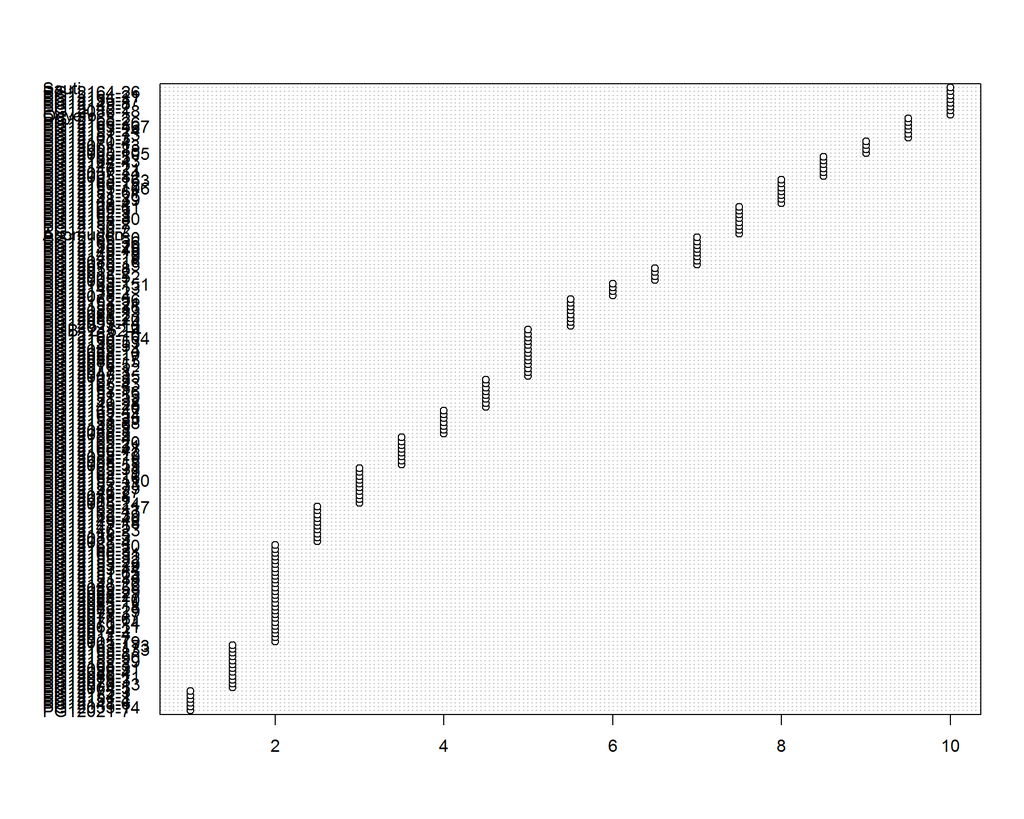

Do not forget the assumptions of the model. It is supposed that the error has a normal distribution with the same variance for all the treatments. The following plots must help you evaluate this:

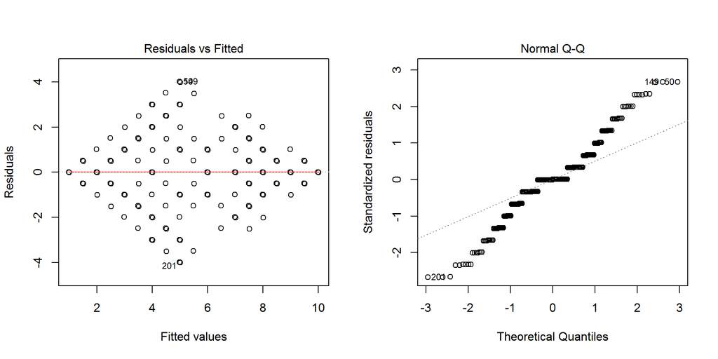

Funnel shapes for the first plot may suggest heterogeneity of variances while departures from the theoretical normal line are symptoms of lack of normality.

### Analysis of **Virus symptoms 2 estimating 1-9**

You have fitted a linear model for a RCBD. The ANOVA table for your model is:

|  | Df | Sum Sq | Mean Sq | F value | Pr(>F) |
| --- | --- | --- | --- | --- | --- |
| **germplasmName** | 162 | 1991.15 | 12.291 | 1.98412 | 8.07863e-06 |
| **REP** | 1 | 12.9601 | 12.9601 | 2.09213 | 0.149991 |
| **Residuals** | 162 | 1003.54 | 6.19469 | NA | NA |

The p-value for treatments is 0.00000807863 which is significant at the 5% level.

The means of your treatments are:

| germplasmName | Virus symptoms 2 estimating 1-9 |
| --- | --- |
| Apomuden | 4.5 |
| Ogyefo | 5 |
| PG12005-1 | 6 |
| PG12005-105 | 4 |
| PG12005-24 | 9.5 |
| PG12005-35 | 8.5 |
| PG12005-52 | 6.5 |
| PG12005-55 | 9.5 |
| PG12005-79 | 10 |
| PG12005-82 | 7 |
| PG12005-88 | 4.5 |
| PG12010-15 | 5.5 |
| PG12011-7 | 10 |
| PG12012-1 | 9.5 |
| PG12012-2 | 6 |
| PG12012-4 | 10 |
| PG12014-2 | 5 |
| PG12021-10 | 8.5 |
| PG12021-7 | 1 |
| PG12028-4 | 9.5 |
| PG12047-3 | 8.5 |
| PG12055-14 | 1 |
| PG12057-14 | 5 |
| PG12058-15 | 9 |
| PG12059-14 | 6.5 |
| PG12059-8 | 5.5 |
| PG12061-13 | 4.5 |
| PG12064-5 | 5.5 |
| PG12069-11 | 10 |
| PG12070-14 | 10 |

[output cut: 133 more lines]

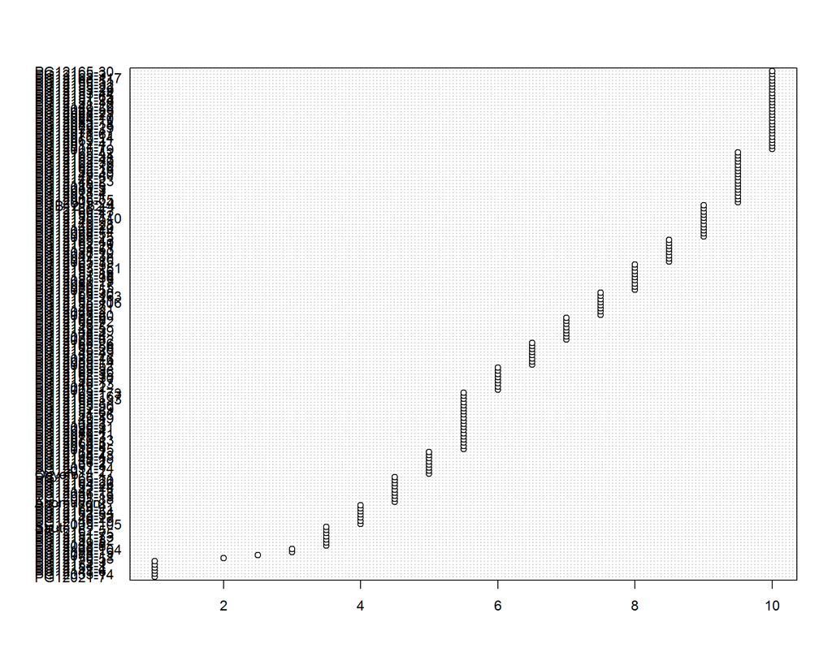

Do not forget the assumptions of the model. It is supposed that the error has a normal distribution with the same variance for all the treatments. The following plots must help you evaluate this:

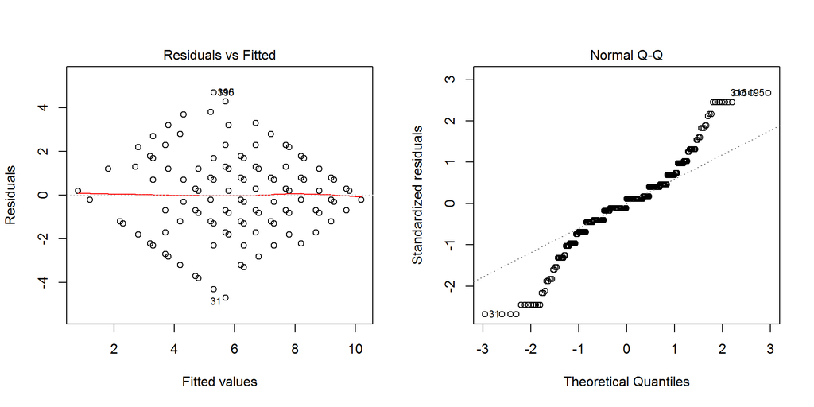

Funnel shapes for the first plot may suggest heterogeneity of variances while departures from the theoretical normal line are symptoms of lack of normality.